# 3. Logistic regression

This week I performed logistic regression analysis. Below you can find the analysis that was performed, more information about the data that was analyzed and the results I got.

```r
date()
```

```
## [1] "Thu Nov 12 09:05:30 2020"
```

Data was loaded from [link](https://archive.ics.uci.edu/ml/machine-learning-databases/00320/) (student.zip file) More information can be found [here](https://archive.ics.uci.edu/ml/datasets/Student+Performance).

Data was described in the web page :“This data approach student achievement in secondary education of two Portuguese schools. The data attributes include student grades, demographic, social and school related features and it was collected by using school reports and questionnaires.” There were two datasets regarding performance in two distinct subjects: Mathematics (mat) and Portuguese language (por). Those datasets were joined together in data wrangling exercise. I am using Reijo Sund´s version of the data in my calculation and it consists of 370 observations of 51 variables. Names of the variables are seen below.

Accessing useful libraries at first:

```r
library(tidyr); library(dplyr); library(ggplot2)
alc_consump <- read.table("~/R/IODS-course/IODS-project/Data/pormath.txt", sep = ",", header=TRUE)
glimpse(alc_consump)
```

```
## Rows: 370
## Columns: 51
## $ school     <chr> "GP", "GP", "GP", "GP", "GP", "GP", "GP", "GP", "GP", "G...
## $ sex        <chr> "F", "F", "F", "F", "F", "F", "F", "F", "F", "F", "F", "...
## $ age        <int> 15, 15, 15, 15, 15, 15, 15, 15, 15, 15, 15, 15, 15, 15, ...
## $ address    <chr> "R", "R", "R", "R", "R", "R", "R", "R", "R", "U", "U", "...
## $ famsize    <chr> "GT3", "GT3", "GT3", "GT3", "GT3", "GT3", "GT3", "LE3", ...
## $ Pstatus    <chr> "T", "T", "T", "T", "T", "T", "T", "T", "T", "A", "A", "...
## $ Medu       <int> 1, 1, 2, 2, 3, 3, 3, 2, 3, 3, 4, 1, 1, 1, 1, 1, 2, 2, 2,...
## $ Fedu       <int> 1, 1, 2, 4, 3, 4, 4, 2, 1, 3, 3, 1, 1, 1, 2, 2, 1, 2, 3,...
## $ Mjob       <chr> "at_home", "other", "at_home", "services", "services", "...
## $ Fjob       <chr> "other", "other", "other", "health", "services", "health...
## $ reason     <chr> "home", "reputation", "reputation", "course", "reputatio...
## $ guardian   <chr> "mother", "mother", "mother", "mother", "other", "mother...
## $ traveltime <int> 2, 1, 1, 1, 2, 1, 2, 2, 2, 1, 1, 3, 1, 1, 1, 1, 3, 1, 2,...
```

[output cut: 38 more lines]

```r
alc_consump$sex <- factor(alc_consump$sex) # Making sex a factor
```

I chose 4 different variables: sex, grades, absences and freetime. My hypotheses are:

1. Male sex has higher alcohol consumption compared to females.
2. Lower grades at school result in greater alcohol consumption.
3. More absences at school can be explained by higher alcohol consumption.
4. More freetime can lead to higher alcohol consumption.

#### Graphical and numerical overview of the chosen variables

##### Sex

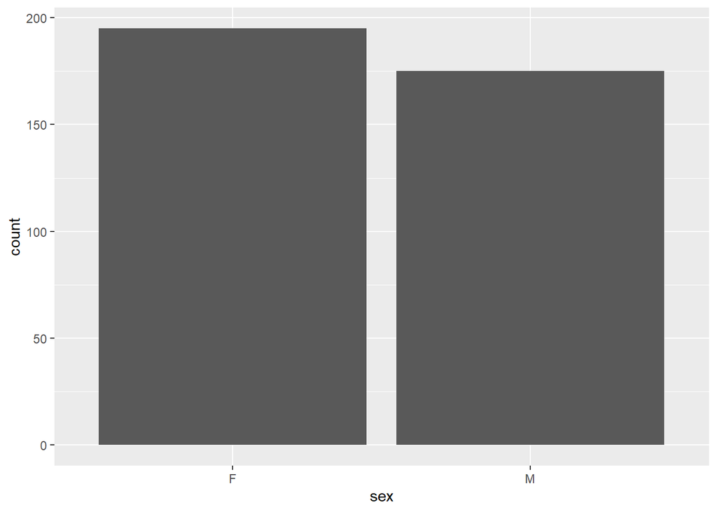

```r
g1 <- ggplot(alc_consump, aes(x=sex)) #bar plot of sex variable
g1 + geom_bar()
```

```r
alc_consump %>% group_by(sex, high_use)%>% summarise(count = n()) #tabular summary of the relationship between sex and high use
```

```
## # A tibble: 4 x 3
## # Groups:   sex [2]
##   sex   high_use count
##   <fct> <lgl>    <int>
## 1 F     FALSE      154
## 2 F     TRUE        41
## 3 M     FALSE      105
## 4 M     TRUE        70
```

There are 195 females and 175 males in the data. From the table above we can see that there are more high alcohol using students in males (70) that in females (41), as I assumed in my first hypothesis.

##### Grades

Next we will see what is the relationship between grades and alcohol consumption. From the bar plot we can see that the distribution of the grades is more on the right side, so most of the grades are good (>10).

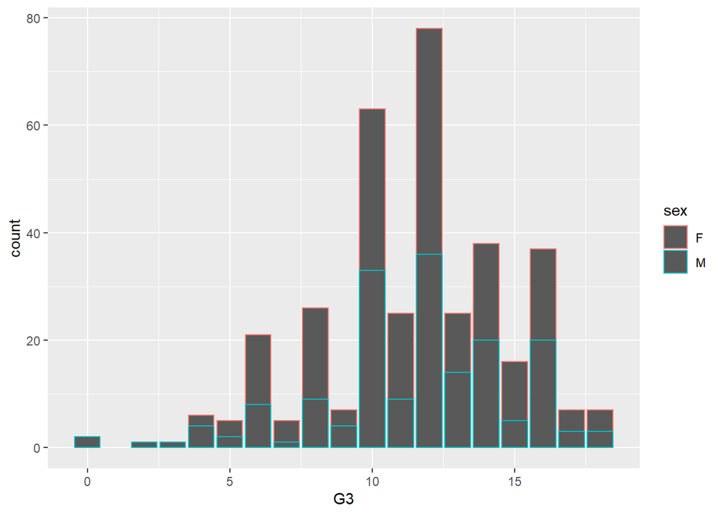

```r
g2 <- ggplot(alc_consump, aes(x=G3, col=sex)) #bar plot of grades
g2 + geom_bar()
```

```r
alc_consump %>% group_by(sex, high_use) %>% summarise(count = n(), mean_grade = mean(G3))
```

```
## # A tibble: 4 x 4
## # Groups:   sex [2]
##   sex   high_use count mean_grade
##   <fct> <lgl>    <int>      <dbl>
## 1 F     FALSE      154       11.4
## 2 F     TRUE        41       11.8
## 3 M     FALSE      105       12.3
## 4 M     TRUE        70       10.3
```

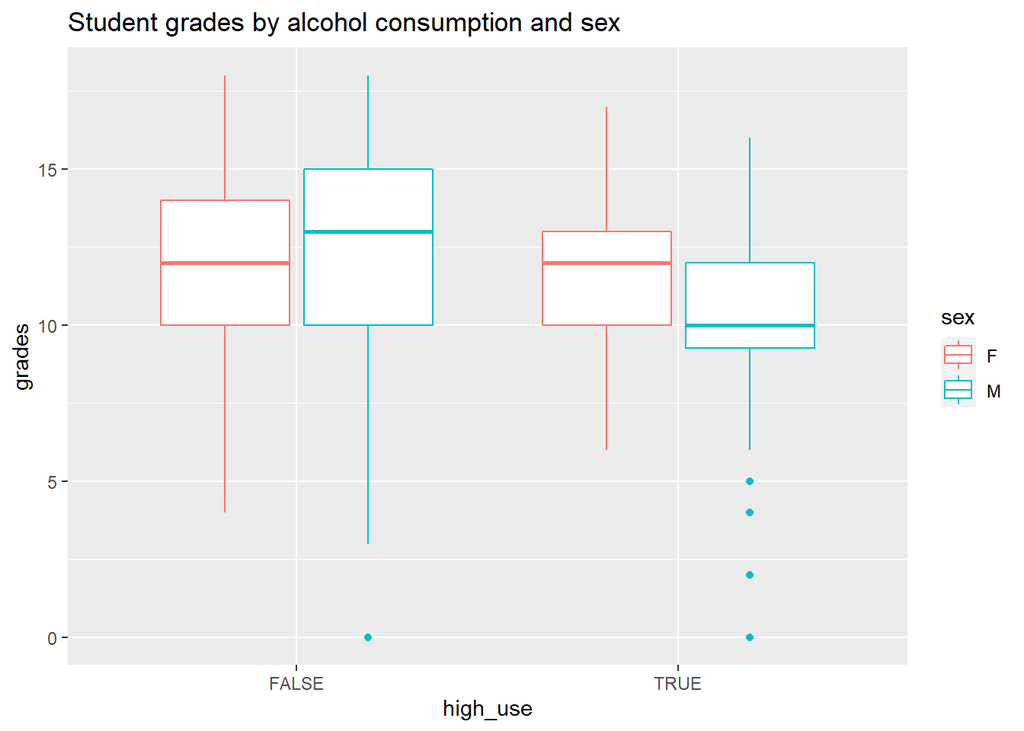

```r
g3 <- ggplot(alc_consump, aes(x = high_use, y = G3, col=sex))#box plot of student grades and high use
g3 + geom_boxplot() + ylab("grades") +ggtitle("Student grades by alcohol consumption and sex")
```

Mean grades in female group don´t differ between high and low alcohol users. But in male group, there is difference between mean grades and it is lower in high alcohol users, which I expected. I also thought that this would be seen in females too.

##### Absences

Distribution of absences is on the left and absences are quite evenly distributed between females and males. Most of the students have 0 or only few absences, but there are few outliers, students who have a lot of absences (>25)

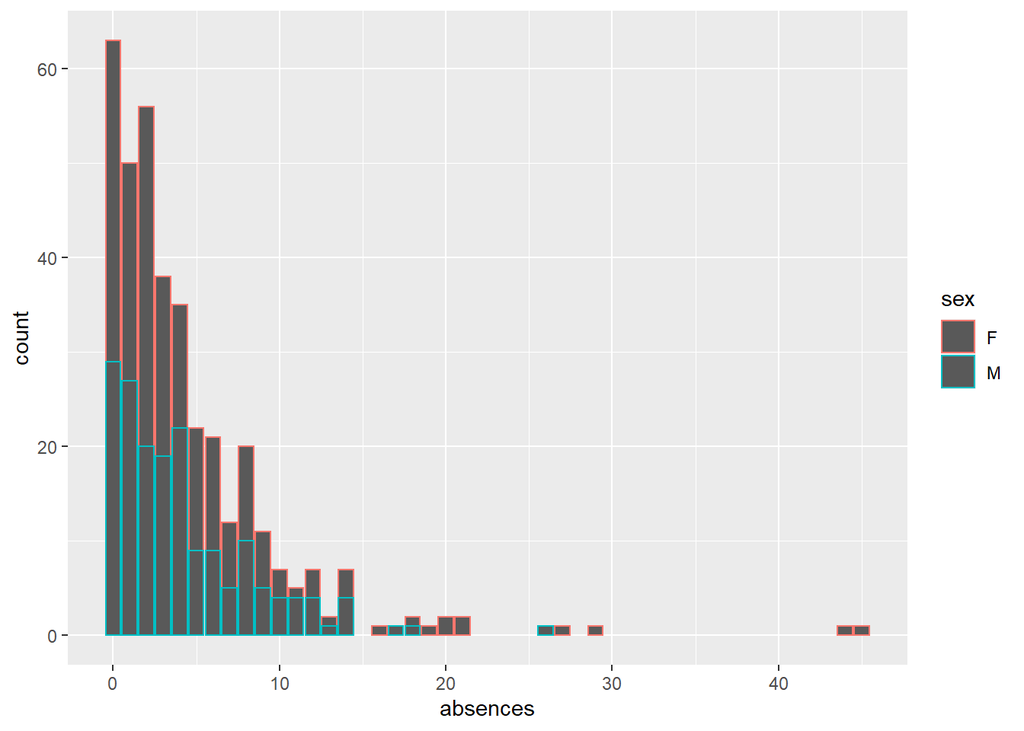

```r
g4 <- ggplot(alc_consump, aes(x=absences, col=sex))#bar plot of absences
g4 + geom_bar()
```

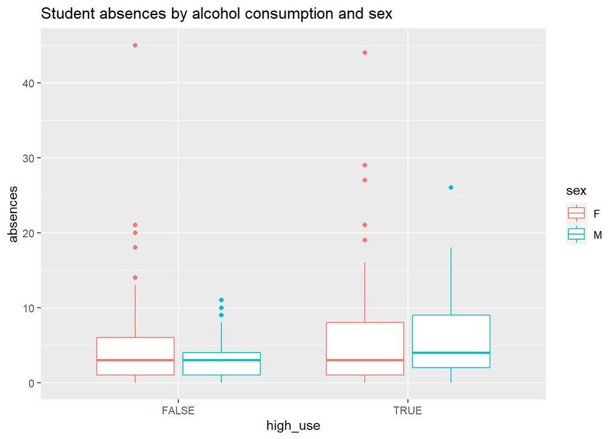

```r
g5 <- ggplot(alc_consump, aes(x = high_use, y = absences, col=sex)) #box plot of high use vs absences
g5 + geom_boxplot() + ylab("absences") +ggtitle("Student absences by alcohol consumption and sex")
```

There is not much difference between the amount of absences in high and low alcohol users on average. But in high alcohol users the variance is greater. Results are quite similar in females and males. My hypothesis was that there would be more absences when alcohol is used. That is somehow right, because the variance is greater.

##### Freetime

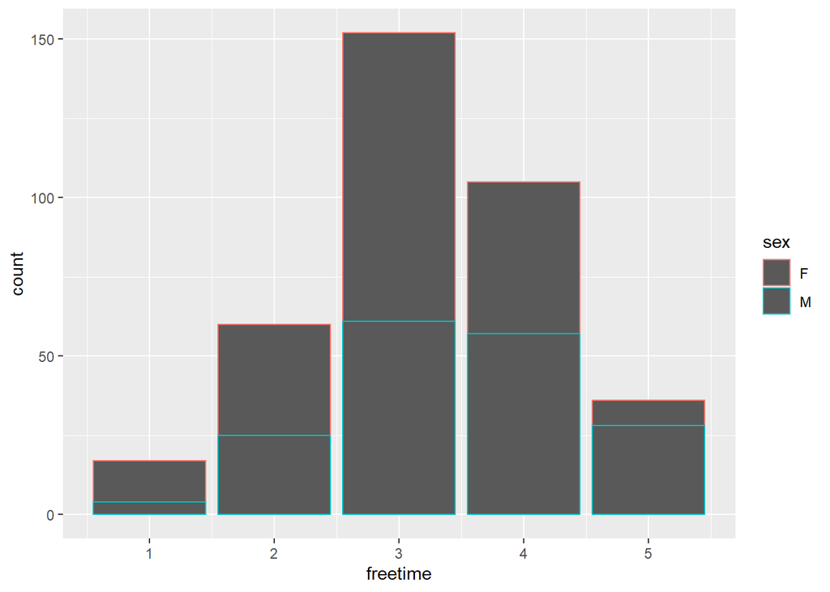

```r
g6 <- ggplot(alc_consump, aes(x=freetime, col=sex))#Freetime bar plot
g6 + geom_bar()
```

Most of the students have medium amount of freetime but females have a bit less freetime than males. And in males, high alcohol users have more freetime on average. In females the variance of freetime in high alcohol users is smaller than in low users. This was also as I assumed in my hypothesis.

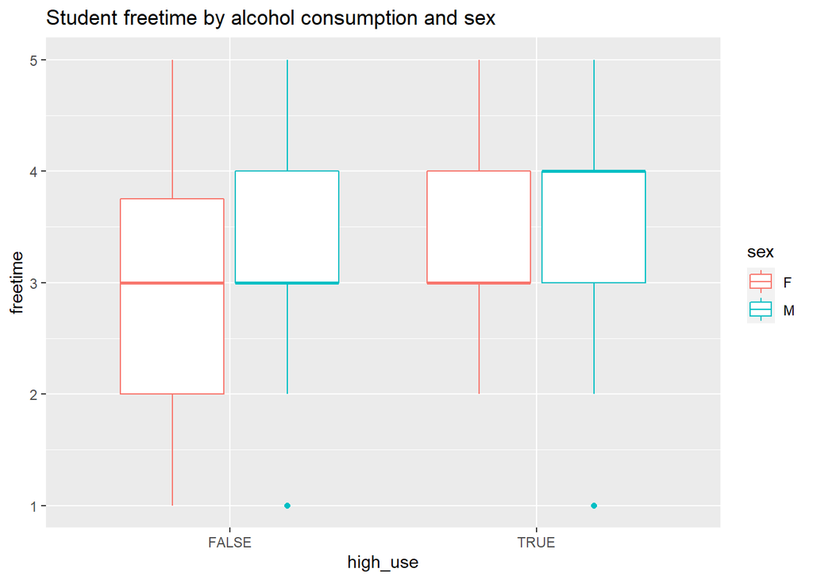

```r
g7 <- ggplot(alc_consump, aes(x = high_use, y = freetime, col=sex)) #box plot of high use vs freetime
g7 + geom_boxplot() + ylab("freetime") +ggtitle("Student freetime by alcohol consumption and sex")
```

#### Logistic regression

I will use logistic regression to statistically explore the relationship between my chosen variables: sex, grades, absences and freetime and the binary high/low alcohol consumption variable as the target variable.

```r
m1 <- glm(high_use ~ G3 + absences + sex + freetime, data = alc_consump, family = "binomial")
summary(m1)
```

```
##
## Call:
## glm(formula = high_use ~ G3 + absences + sex + freetime, family = "binomial",
##     data = alc_consump)
##
## Deviance Residuals:
##     Min       1Q   Median       3Q      Max
## -1.9992  -0.8376  -0.5967   1.0688   2.1281
##
## Coefficients:
##             Estimate Std. Error z value Pr(>|z|)
## (Intercept) -1.92263    0.63340  -3.035  0.00240 **
## G3          -0.07636    0.03706  -2.061  0.03935 *
## absences     0.09410    0.02323   4.050 5.12e-05 ***
## sexM         0.92938    0.25150   3.695  0.00022 ***
## freetime     0.30444    0.12845   2.370  0.01778 *
## ---
## Signif. codes:  0 '***' 0.001 '**' 0.01 '*' 0.05 '.' 0.1 ' ' 1
##
## (Dispersion parameter for binomial family taken to be 1)
##
##     Null deviance: 452.04  on 369  degrees of freedom
## Residual deviance: 405.20  on 365  degrees of freedom
## AIC: 415.2
##
## Number of Fisher Scoring iterations: 4
```

If we now look at the summary of the fitted model, we can see the model estimates and parameters and also the p-values of the statistical test (Pr(>|z|)). If we look at the p-values, all of them are smaller that 0,05, so all of the chosen variables are statistically significant. If we compare the p-values, grades (G3) has the highest value 0,0393 which is quite close to 0,05. So with grades the significance is not so great as for example in the case of absences. The p-value for absences is very small 5.12e-05, which means that there is statistically significant relationship between absences and high alcohol consumption. In the summary sexM, means that when comparing females to males, male sex has statistically significant relationship between high alcohol consumption, p-value 0,00022. However, there are statistically significant relationships between all the chosen variables and high alcohol consumption.

Next I will present the coefficients of the model as odds ratios, including confidence intervals

```r
OR <- coef(m1) %>% exp #computing odds ratios
CI <- confint(m1) %>% exp #computing confidence intervals
cbind(OR, CI) #printing out the odds ratios with their confidence intervals
```

```
##                    OR      2.5 %    97.5 %
## (Intercept) 0.1462213 0.04110958 0.4958846
## G3          0.9264847 0.86089482 0.9960244
## absences    1.0986708 1.05199101 1.1525937
## sexM        2.5329476 1.55515113 4.1769987
## freetime    1.3558665 1.05718812 1.7513727
```

Now we can see ORs. We also need the original coefficients of the model for explaining the results.

```r
coef(m1)
```

```
## (Intercept)          G3    absences        sexM    freetime
## -1.92263391 -0.07635776  0.09410107  0.92938367  0.30444073
```

absences: OR is 1,10, and the coefficient is positive 0,094, which means that when absences increase by one, the probability of high alcohol consumption increases 1,10 fold.

sexM: OR is 2,53 and the coefficient is positive 0,93, which means that when we compare females to males, being male increases the probability of high alcohol consumption 2,53 fold. SexM has also the widest CI [1.55, 4.17].

freetime: OR is 1.36 and the coefficient is positive 0,30, which means that when freetime increases, the probability of high alcohol consumption increases 1,36 fold.

#### Model predictions

I will use variables absences, sex and freetime while making the predictions of the fitted model.

```r
m2 <- glm(high_use ~ absences + sex + freetime, data = alc_consump, family = "binomial")#creating new model m2 with 3 variables
summary(m2)
```

```
##
## Call:
## glm(formula = high_use ~ absences + sex + freetime, family = "binomial",
##     data = alc_consump)
##
## Deviance Residuals:
##     Min       1Q   Median       3Q      Max
## -2.0218  -0.8343  -0.6067   1.0385   2.0171
##
## Coefficients:
##             Estimate Std. Error z value Pr(>|z|)
## (Intercept) -2.82988    0.47008  -6.020 1.74e-09 ***
## absences     0.09829    0.02321   4.236 2.28e-05 ***
## sexM         0.91934    0.24968   3.682 0.000231 ***
## freetime     0.31191    0.12729   2.450 0.014268 *
## ---
## Signif. codes:  0 '***' 0.001 '**' 0.01 '*' 0.05 '.' 0.1 ' ' 1
##
## (Dispersion parameter for binomial family taken to be 1)
##
##     Null deviance: 452.04  on 369  degrees of freedom
## Residual deviance: 409.48  on 366  degrees of freedom
## AIC: 417.48
##
## Number of Fisher Scoring iterations: 4
```

```r
probabilities <- predict(m2, type = "response") # predicting the probability of high_use, with new model m2

alc_consump <- mutate(alc_consump, probability = probabilities) # adding the predicted probabilities to 'alc_consump'

alc_consump <- mutate(alc_consump, prediction = probability > 0.5) # using the probabilities to make a prediction of high_use

select(alc_consump, absences, sex, freetime, high_use, probability, prediction) %>% tail(10)# checking the last ten original classes, predicted probabilities, and class predictions
```

```
##     absences sex freetime high_use probability prediction
## 361        7   M        4     TRUE   0.5062786       TRUE
## 362        3   M        3     TRUE   0.3362730      FALSE
## 363        2   M        4     TRUE   0.3854857      FALSE
## 364        4   M        2     TRUE   0.2903743      FALSE
## 365        3   M        3    FALSE   0.3362730      FALSE
## 366        4   M        3     TRUE   0.3585510      FALSE
## 367        0   M        2    FALSE   0.2164082      FALSE
## 368        4   M        4     TRUE   0.4329684      FALSE
## 369        8   M        4     TRUE   0.5308120       TRUE
## 370        0   M        3    FALSE   0.2739221      FALSE
```

```r
table(high_use = alc_consump$high_use, prediction = alc_consump$prediction) # tabulating the target variable versus the predictions
```

```
##         prediction
## high_use FALSE TRUE
##    FALSE   245   14
##    TRUE     83   28
```

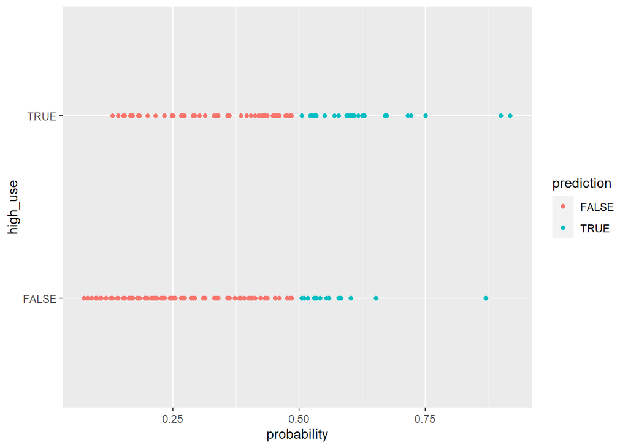

```r
g_p <- ggplot(alc_consump, aes(x = probability, y = high_use,col =prediction )) # initializing a plot of 'high_use' versus 'probability' in 'alc_consump'

 g_p + geom_point()# defining the geom as points and drawing the plot
```

```r
# tabulating the target variable versus the predictions
table(high_use = alc_consump$high_use, prediction = alc_consump$prediction) %>% prop.table() %>% addmargins()
```

```
##         prediction
## high_use      FALSE       TRUE        Sum
##    FALSE 0.66216216 0.03783784 0.70000000
##    TRUE  0.22432432 0.07567568 0.30000000
##    Sum   0.88648649 0.11351351 1.00000000
```

Calculating the mean predictive error and average number of wrong predictions to see how well predictions are made

```r
loss_func <- function(class, prob) { # defining a loss function (mean prediction error)
  n_wrong <- abs(class - prob) > 0.5
  mean(n_wrong)
}

loss_func(class = alc_consump$high_use, prob = 0) # calling loss_func to compute the average number of wrong predictions in the data
```

```
## [1] 0.3
```